# Examen parcial 1 - Métodos Cuantitativos en Ecología

David Andrade Dominguez

23 de mayo de 2023

Bienvenidos al examen parcial de Métodos Cuantitativos en Ecología [MCE5 - 2023I]. Para esta evaluación utilice este cuaderno de R Markdown y tenga en cuenta las siguientes instruciones:

- **FUNDAMENTAL: La entrega es el enlace de GitHub.** A partir de una bifurcación de la carpeta del examen de GitHub, cree una carpeta en su computador donde guarden este cuaderno .Rmd y la data que van a utilizar. Definan a esa carpeta como su directorio de trabajo.
- Arriba, donde dice “author”, deben cambiar por sus datos.
- Los codigos deben ser escritos dentro de las cajas `{r}` o dentro de las cajas indicadas abajo de las preguntas.
- Genere un documento html de este cuaderno .Rmd.
- Guarde todos los documentos y figuras en una carpeta “mce5_exame1”, copie y pegue el enlace en el aula virtual, donde dice “ExamenParcial1”.
- **FUNDAMENTAL: No imprima tablas completas, si quiere mostrar algo use la función `head()`.**
- **FUNDAMENTAL: Todo bloque de código (30%) debe ir acompañado de una explicación del resultado (70%). Si no tiene la explicación no será considerado para calificar.**
- **FUNDAMENTAL: La honestidad académica es fundamental en su formación, escriba ideas propias, evite el plagio y la copia que incluye el uso indebido de herramientas de inteligencia artificial.**

# 1 **[2 PUNTOS] Control de cambios.**

- Realice la bifurcación de la carpeta del Examen
- Cree una carpeta en su conputador con “Control de Cambios” usando Git
- Cada vez que responda una pregunta, envíe los cambios con un `commit` similar a `Apellido Nombre ha realizado el ejercicio ##`.

# 2 **[2 PUNTOS] Diseño, especies raras.**

En el estudio realizado por [Sanches -Martin R., Verdú M. y Montensinos-Navarro A. (2023)](https://doi.org/10.1111/jvs.13185) evaluan cómo la facilitación interespecífica puede mantener la diversidad a lo largo de la vida de la especie al evitar la extinción de especies localmente raras en etapas juveniles y reducir las disparidades de rendimiento entre vecinos de diferentes especies en etapas maduras.. Suponga que quiere replicar este estudio en alguna zona del Ecuador. Para ello inicie respondiendo las siguientes preguntas:

## 2.1 Para su potencial investigación ¿Cuál sería su hipótesis ? (Explique)

**Respuesta:**

Todas las plantas tienen la misma necesidad de recursos dependiendo su ubicacion. Si las especies recibieran por igual la cantidad de recursos, no existiria competencia y por ende no se perdera la diversidad. Si las especies recibieran por desigual la cantidad de recursos, existiria competencia y por ende se perdera la diversidad.

## 2.2 Muestra

Replique el diseño realizado en el artículo en localidades del Ecuador y genere el archivo **rarespecies.csv**.

```r
library(agricolae)
sitios <-c("Parque Historico", "Pantanal", "Manglar Ecomundo")
r <- 3
seed = 100
crd1 <-design.crd(trt= sitios,
                  r = r,
                  serie=2,
                  seed = seed,
                  kind = "Super-Duper",
                  randomization = TRUE)
crd_re <- crd1$book
crd_re$Etapas <- NaN
crd_re$Rendimiento<- NaN
crd_re$Diversidad<-NaN

# write to hard disk
write.csv(crd_re,"rarespecies.csv", row.names=FALSE, sep=";")
# file.show("crd.txt")
```

Explique el resultado muestra:

**Respuesta:**

En el estudio que se pretende realizar, se tomo 9 muestras de especies que se situan en la ciudad de Guayaquil - Ecuador.

## 2.3 Variables

¿Cuáles son sus variables (dependiente(s) e independiente(s))? Explique cada una de las variables

**Respuesta:**

Como variables tenemos 6 que serian la ubicacion de las muestras, la etapa en la que se encuentran, el rendimiento que tiene en ese espacio y la diversidad que presenta.

## 2.4 Gráfica e hipótesis

En una hoja de papel dibuje un gráfico hipotetico basado en la figura 4 del artículo mostrando [Coloque adecuadamente las leyendas]. Describa su figura justifique su razonamiento.

**Respuesta (adjunte una foto de la imagen o genere una gráfica con código)**

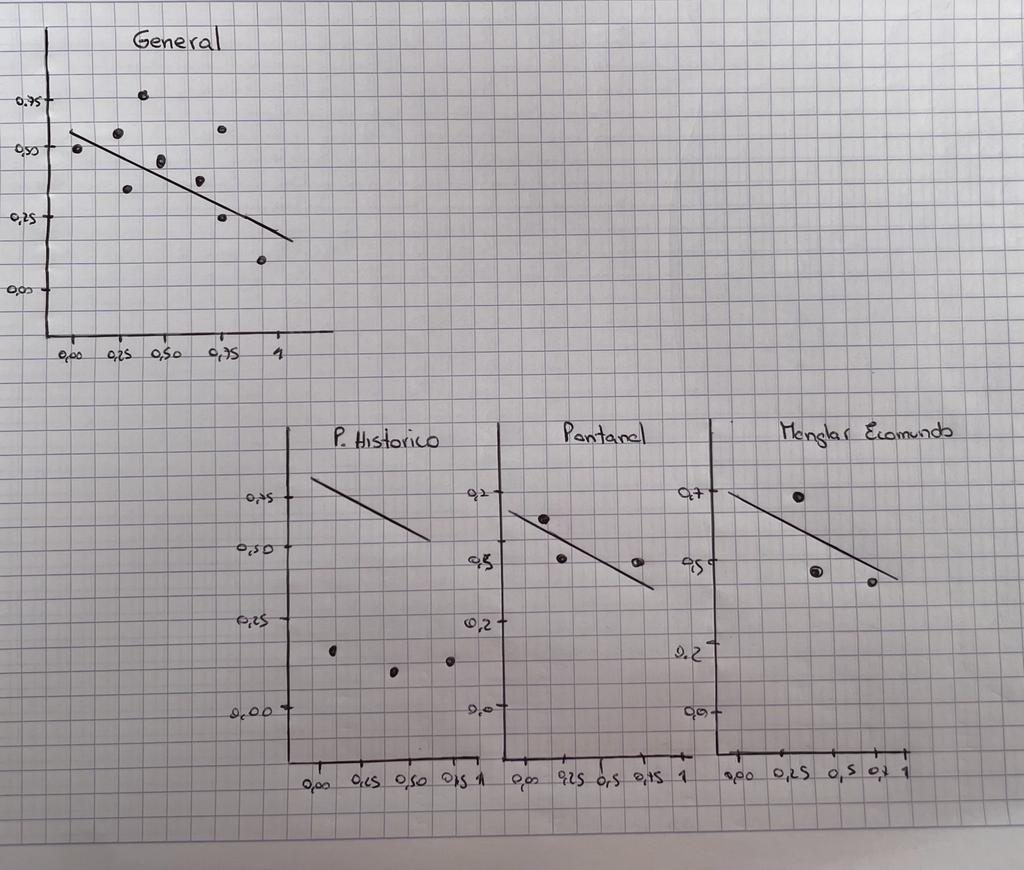

Gráfico Hipotetico

En este graficos podemos ver la ubicacion de las especies que tenemos como muestras, tanto una general como una grafica de cada ubicacion.

# 3 **[6 PUNTOS] Regresiones

En esta parte debe aplicar las regresiones lineal, linearizada y generalizada sobre la presencia de ácaros en musgos. Una de las especies analizadas es *Galumma sp.* cuya abundancia presencia y proporción es posiblemente afectada por las siguiente cinco variables ambientales como densidad de sustrato, el tipo de sustrato, el contenido de agua, si se tiene o no arbustos en la cercanía y la topografía del suelo. Utilice la data `mites.csv` y responda los siguientes items.

¿Cuál es el efecto de las variables ambientales en la i) abundancia de ii) abundancia y iii) proporción de la especie *Galumma sp.*?

Para responder esta pregunta debe generar las hipótesis y probar las hipótesis (código y explicación), asimismo visualizar con etiquetas adecuadas. Considere realizar lo siguiente:

- Realizar un análisis exploratorio.

```r
library(readr)
mites <- read_csv("mites.csv")
View(mites)
str(mites)
```

```
## spc_tbl_ [70 × 9] (S3: spec_tbl_df/tbl_df/tbl/data.frame)
##  $ AbundanceGalumma: num [1:70] 8 3 1 1 2 1 1 1 2 5 ...
##  $ Ocurrence       : num [1:70] 1 1 1 1 1 1 1 1 1 1 ...
##  $ AdundanceTotal  : num [1:70] 140 268 186 286 199 209 162 126 123 166 ...
##  $ Proportion      : num [1:70] 0.05714 0.01119 0.00538 0.0035 0.01005 ...
##  $ SubstrateDensity: num [1:70] 39.2 55 46.1 48.2 23.6 ...
##  $ WaterContent    : num [1:70] 350 435 372 360 204 ...
##  $ Substrate       : chr [1:70] "Sphagn1" "Litter" "Interface" "Sphagn1" ...
##  $ Shrub           : chr [1:70] "Few" "Few" "Few" "Few" ...
##  $ Topography      : chr [1:70] "Hummock" "Hummock" "Hummock" "Hummock" ...
##  - attr(*, "spec")=
##   .. cols(
##   ..   AbundanceGalumma = col_double(),
##   ..   Ocurrence = col_double(),
##   ..   AdundanceTotal = col_double(),
##   ..   Proportion = col_double(),
##   ..   SubstrateDensity = col_double(),
##   ..   WaterContent = col_double(),
##   ..   Substrate = col_character(),
##   ..   Shrub = col_character(),
##   ..   Topography = col_character()
##   .. )
##  - attr(*, "problems")=<externalptr>
```

```r
attach(mites)
```

```r
summary(mites)
```

```
##  AbundanceGalumma   Ocurrence      AdundanceTotal     Proportion
##  Min.   :0.0000   Min.   :0.0000   Min.   :  8.00   Min.   :0.000000
##  1st Qu.:0.0000   1st Qu.:0.0000   1st Qu.: 97.75   1st Qu.:0.000000
##  Median :0.0000   Median :0.0000   Median :121.00   Median :0.000000
##  Mean   :0.9571   Mean   :0.3571   Mean   :140.00   Mean   :0.005764
##  3rd Qu.:1.0000   3rd Qu.:1.0000   3rd Qu.:161.00   3rd Qu.:0.009656
##  Max.   :8.0000   Max.   :1.0000   Max.   :781.00   Max.   :0.057143
##  SubstrateDensity  WaterContent    Substrate            Shrub
##  Min.   :21.17    Min.   :134.1   Length:70          Length:70
##  1st Qu.:30.01    1st Qu.:314.1   Class :character   Class :character
##  Median :36.38    Median :398.5   Mode  :character   Mode  :character
##  Mean   :39.28    Mean   :410.6
##  3rd Qu.:46.81    3rd Qu.:492.8
##  Max.   :80.59    Max.   :827.0
##   Topography
##  Length:70
##  Class :character
##  Mode  :character
##
##
##
```

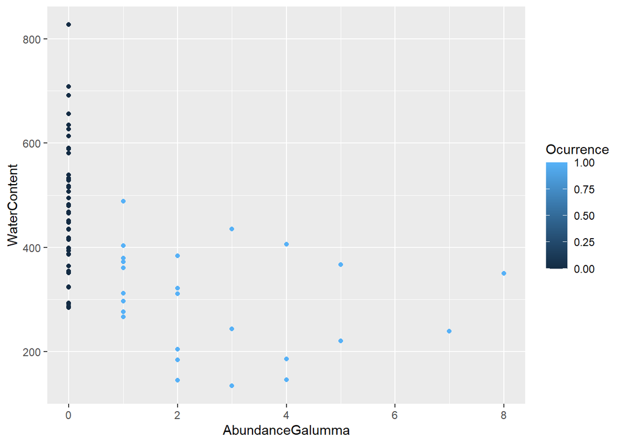

```r
library(ggplot2)
ggplot(data = mites, aes(x = AbundanceGalumma, y = WaterContent,
                          col = Ocurrence)) +
  geom_point()
```

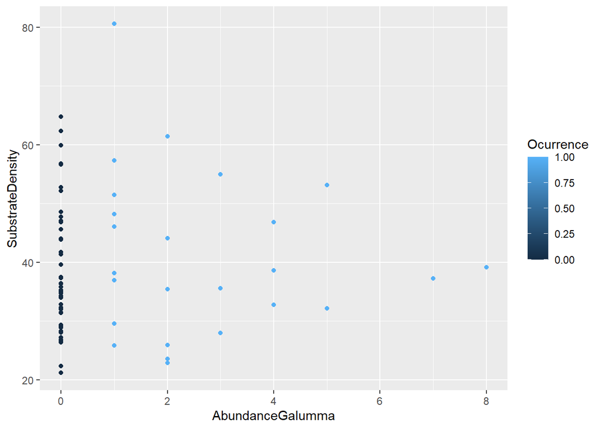

```r
library(ggplot2)
ggplot(data = mites, aes(x = AbundanceGalumma, y = SubstrateDensity,
                          col = Ocurrence)) +
  geom_point()
```

En la figura se muestra que a medida que hay abundacia la contención de agua en los sustratos disminuye en los musgos.

- Realizar regresiones lineales de cada variable de respuesta y variables efectoras, univariable o multivariable. Verifique los supuestos de la regresión.

$H_{01}$: El incremneto de la abundancia de galuma no produce un efecto en la contención de agua en los musgos y en la densidad de los substratos $H_{02}$: El incremento de la abundancia de galuma tieneun efecto en la contención de agua en los musgos y en la densidad de los substratos.

```r
lm1 = lm(AbundanceGalumma ~WaterContent, data = mites)
summary(lm1)
```

```
##
## Call:
## lm(formula = AbundanceGalumma ~ WaterContent, data = mites)
##
## Residuals:
##     Min      1Q  Median      3Q     Max
## -1.7210 -0.8236 -0.3270  0.3910  6.6772
##
## Coefficients:
##               Estimate Std. Error t value Pr(>|t|)
## (Intercept)   3.439349   0.555825   6.188 3.98e-08 ***
## WaterContent -0.006045   0.001280  -4.723 1.21e-05 ***
## ---
## Signif. codes:  0 '***' 0.001 '**' 0.01 '*' 0.05 '.' 0.1 ' ' 1
##
## Residual standard error: 1.514 on 68 degrees of freedom
## Multiple R-squared:  0.247,  Adjusted R-squared:  0.2359
## F-statistic: 22.31 on 1 and 68 DF,  p-value: 1.206e-05
```

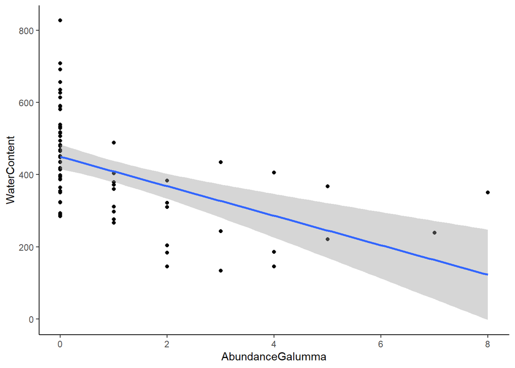

```r
ggplot(mites, aes(x=AbundanceGalumma, y = WaterContent)) +
  geom_point() +
  geom_smooth(method="lm") + theme_classic()
```

```r
cond1 = sum(lm1$residuals)
cond1
```

```
## [1] -1.071365e-14
```

## 3.1 ii. Linearidad

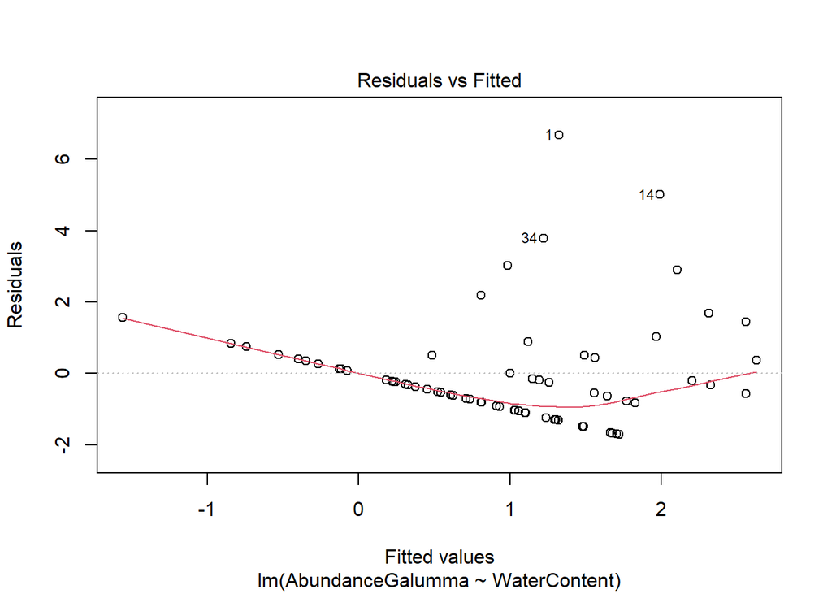

```r
plot(lm1, 1)
```

## 3.2 iii. Normalidad de los residuales

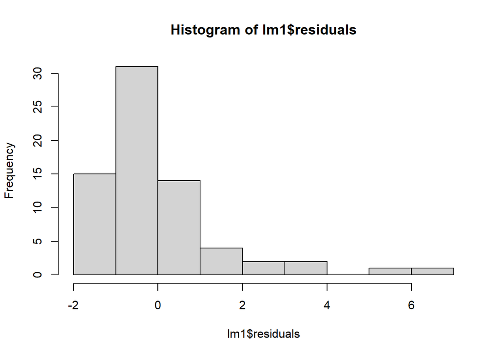

```r
hist(lm1$residuals)
```

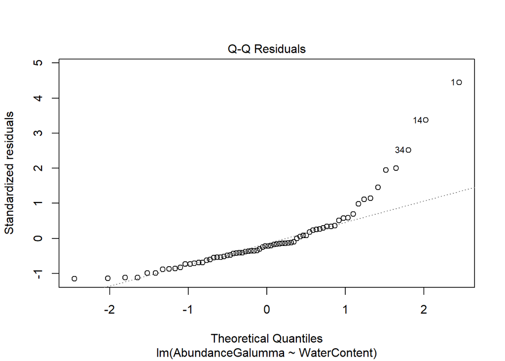

```r
plot(lm1, 2)
```

Aunque el histograma dice que aparenetemente no es normal, el q-q plot indica que solamente algunos puntos afectan a esa normalidad (1, 34, 14) en si nuestros valores atipicos.

$H_0: $ la distribución es normal ($CI:95%, p>0.05$)

```r
shapiro.test(lm1$residuals)
```

```
##
##  Shapiro-Wilk normality test
##
## data:  lm1$residuals
## W = 0.79327, p-value = 1.59e-08
```

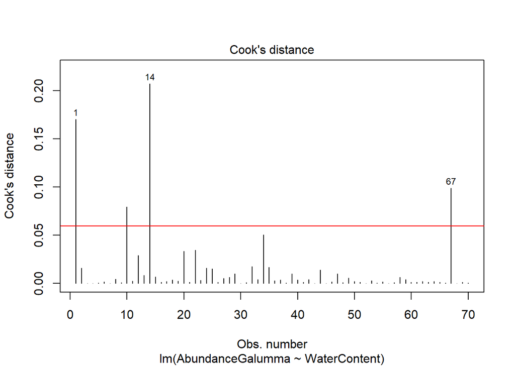

```r
plot(lm1, 4)
abline(h=4/(length(lm1$residuals)-2-1), col="red")
```

```r
k = 2  # numero de variables
N = length(lm1$residuals)  #número de observaciones
umbral_cookd = 4/(N-k-1)
umbral_cookd
```

```
## [1] 0.05970149
```

```r
sort(cooks.distance(lm1), decreasing = TRUE)
```

```
##           14            1           67           10           34           22
## 2.072071e-01 1.701848e-01 9.879547e-02 7.955202e-02 5.033327e-02 3.461217e-02
##           20           12           32           35            2           24
## 3.340629e-02 2.919154e-02 1.750536e-02 1.676276e-02 1.584029e-02 1.574482e-02
##           25           44           29           39           47           13
## 1.531571e-02 1.408777e-02 9.915066e-03 9.865661e-03 9.793203e-03 8.555833e-03
##           15           58           28           49           27            8
## 6.631674e-03 6.374266e-03 6.268110e-03 5.490457e-03 5.077893e-03 4.602489e-03
##           42           33           59           18           37           40
## 4.028778e-03 3.979006e-03 3.937809e-03 3.698116e-03 3.659568e-03 3.447127e-03
##           23           53           36           19           11           17
## 3.423505e-03 2.795096e-03 2.679979e-03 2.582038e-03 2.395532e-03 2.236088e-03
##           50           64           62           55           46            6
## 2.188806e-03 2.170307e-03 1.919978e-03 1.848156e-03 1.758980e-03 1.501413e-03
##           51           60           41           61           21           69
## 1.455889e-03 1.444820e-03 1.396163e-03 1.376913e-03 1.320630e-03 1.174936e-03
##           65           16           63           26            9           31
## 1.171830e-03 1.160243e-03 1.116320e-03 1.114545e-03 9.402346e-04 8.931715e-04
##           57           48           66           70            5           38
## 7.513752e-04 6.711435e-04 5.387664e-04 4.987557e-04 4.520377e-04 3.332239e-04
##           54           56            4           45           68            3
## 3.046416e-04 2.729711e-04 2.455072e-04 2.027226e-04 1.434217e-04 1.280549e-04
##           52            7           43           30
## 1.180445e-04 7.473623e-05 4.337922e-05 5.994046e-09
```

## 3.3 v. Homogeneidad de varianzas (Homocedasticidad)

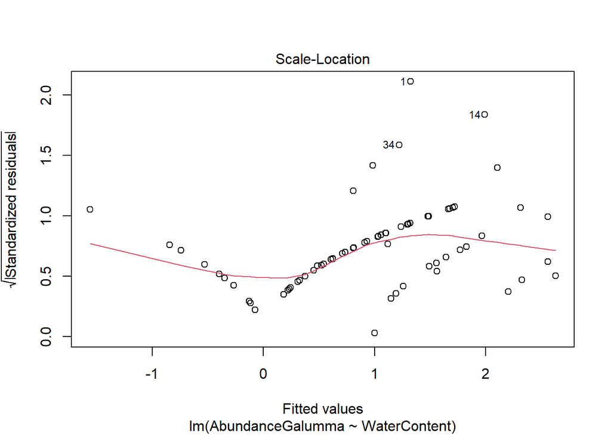

```r
plot(lm1, 3)
```

- Realizar regresiones linearizadas de cada variable de respuesta y variables efectoras, univariable o multivariable.

## 3.4 Linearización

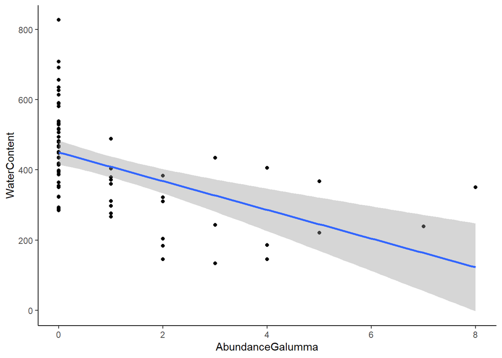

```r
ggplot(mites, aes(x=AbundanceGalumma, y = WaterContent)) +
  geom_point() +
  geom_smooth(method="lm") + theme_classic()
```

Luego de que se observa que algunos puntos están muy alejados de la recta y que la recta no se ajusta a la mayoría de puntos por lo cuál tiene un comportamiento “extraño”.

Para corregir se recurre a las transformaciones, también denominadas “linearización”